# Risk Factor Analysis

## Outcome Variable

**Outcome Variable:** stunted

## Predictor Variables

**Intervention Variable:** safeh20

**Adjustment Set:**

- arm
- sex
- W_mage
- meducyrs
- feducyrs
- hhwealth_quart
- hfoodsec
- W_mhtcm
- W_nrooms
- W_nchldlt5
- W_parity
- impfloor
- impsan
- delta_W_mage
- delta_meducyrs
- delta_feducyrs
- delta_hhwealth_quart
- delta_hfoodsec
- delta_W_mhtcm
- delta_W_nrooms
- delta_W_nchldlt5
- delta_W_parity
- delta_impfloor
- delta_impsan

## Stratifying Variables

The analysis was stratified on these variable(s):

- agecat
- studyid
- country

## Data Summary

| agecat | studyid | country | safeh20 | stunted | n_cell | n |
| --- | --- | --- | --- | --- | --- | --- |
| Birth | ki0047075b-MAL-ED | BANGLADESH | 0 | 0 | 196 | 234 |
| Birth | ki0047075b-MAL-ED | BANGLADESH | 0 | 1 | 38 | 234 |
| 6 months | ki0047075b-MAL-ED | BANGLADESH | 0 | 0 | 195 | 240 |
| 6 months | ki0047075b-MAL-ED | BANGLADESH | 0 | 1 | 45 | 240 |
| 24 months | ki0047075b-MAL-ED | BANGLADESH | 0 | 0 | 114 | 212 |
| 24 months | ki0047075b-MAL-ED | BANGLADESH | 0 | 1 | 98 | 212 |
| Birth | ki0047075b-MAL-ED | BRAZIL | 0 | 0 | 113 | 124 |
| Birth | ki0047075b-MAL-ED | BRAZIL | 0 | 1 | 11 | 124 |
| 6 months | ki0047075b-MAL-ED | BRAZIL | 0 | 0 | 140 | 142 |
| 6 months | ki0047075b-MAL-ED | BRAZIL | 0 | 1 | 2 | 142 |
| 24 months | ki0047075b-MAL-ED | BRAZIL | 0 | 0 | 110 | 113 |
| 24 months | ki0047075b-MAL-ED | BRAZIL | 0 | 1 | 3 | 113 |
| Birth | ki0047075b-MAL-ED | INDIA | 0 | 0 | 161 | 191 |
| Birth | ki0047075b-MAL-ED | INDIA | 0 | 1 | 30 | 191 |
| 6 months | ki0047075b-MAL-ED | INDIA | 0 | 0 | 190 | 235 |
| 6 months | ki0047075b-MAL-ED | INDIA | 0 | 1 | 45 | 235 |
| 24 months | ki0047075b-MAL-ED | INDIA | 0 | 0 | 132 | 227 |
| 24 months | ki0047075b-MAL-ED | INDIA | 0 | 1 | 95 | 227 |
| 6 months | ki0047075b-MAL-ED | NEPAL | 0 | 0 | 221 | 233 |
| 6 months | ki0047075b-MAL-ED | NEPAL | 0 | 1 | 11 | 233 |
| 6 months | ki0047075b-MAL-ED | NEPAL | 1 | 0 | 1 | 233 |
| 6 months | ki0047075b-MAL-ED | NEPAL | 1 | 1 | 0 | 233 |
| 24 months | ki0047075b-MAL-ED | NEPAL | 0 | 0 | 176 | 226 |
| 24 months | ki0047075b-MAL-ED | NEPAL | 0 | 1 | 49 | 226 |
| 24 months | ki0047075b-MAL-ED | NEPAL | 1 | 0 | 1 | 226 |
| 24 months | ki0047075b-MAL-ED | NEPAL | 1 | 1 | 0 | 226 |
| Birth | ki0047075b-MAL-ED | NEPAL | 0 | 0 | 150 | 168 |
| Birth | ki0047075b-MAL-ED | NEPAL | 0 | 1 | 17 | 168 |
| Birth | ki0047075b-MAL-ED | NEPAL | 1 | 0 | 1 | 168 |
| Birth | ki0047075b-MAL-ED | NEPAL | 1 | 1 | 0 | 168 |

[output cut: 96 more lines]

The following strata were considered:

- agecat: 24 months, studyid: ki0047075b-MAL-ED, country: BANGLADESH
- agecat: 24 months, studyid: ki0047075b-MAL-ED, country: BRAZIL
- agecat: 24 months, studyid: ki0047075b-MAL-ED, country: INDIA
- agecat: 24 months, studyid: ki0047075b-MAL-ED, country: NEPAL
- agecat: 24 months, studyid: ki0047075b-MAL-ED, country: PERU
- agecat: 24 months, studyid: ki0047075b-MAL-ED, country: SOUTH AFRICA
- agecat: 24 months, studyid: ki0047075b-MAL-ED, country: TANZANIA, UNITED REPUBLIC OF
- agecat: 24 months, studyid: ki1017093-NIH-Birth, country: BANGLADESH
- agecat: 24 months, studyid: ki1017093b-PROVIDE, country: BANGLADESH
- agecat: 24 months, studyid: ki1017093c-NIH-Crypto, country: BANGLADESH
- agecat: 24 months, studyid: ki1114097-CONTENT, country: PERU
- agecat: 24 months, studyid: ki1148112-LCNI-5, country: MALAWI
- agecat: 24 months, studyid: kiGH5241-JiVitA-3, country: BANGLADESH
- agecat: 24 months, studyid: kiGH5241-JiVitA-4, country: BANGLADESH
- agecat: 6 months, studyid: ki0047075b-MAL-ED, country: BANGLADESH
- agecat: 6 months, studyid: ki0047075b-MAL-ED, country: BRAZIL
- agecat: 6 months, studyid: ki0047075b-MAL-ED, country: INDIA
- agecat: 6 months, studyid: ki0047075b-MAL-ED, country: NEPAL
- agecat: 6 months, studyid: ki0047075b-MAL-ED, country: PERU
- agecat: 6 months, studyid: ki0047075b-MAL-ED, country: SOUTH AFRICA
- agecat: 6 months, studyid: ki0047075b-MAL-ED, country: TANZANIA, UNITED REPUBLIC OF
- agecat: 6 months, studyid: ki1000304b-SAS-FoodSuppl, country: INDIA
- agecat: 6 months, studyid: ki1017093-NIH-Birth, country: BANGLADESH
- agecat: 6 months, studyid: ki1017093b-PROVIDE, country: BANGLADESH
- agecat: 6 months, studyid: ki1017093c-NIH-Crypto, country: BANGLADESH
- agecat: 6 months, studyid: ki1114097-CONTENT, country: PERU
- agecat: 6 months, studyid: ki1148112-LCNI-5, country: MALAWI
- agecat: 6 months, studyid: kiGH5241-JiVitA-3, country: BANGLADESH
- agecat: 6 months, studyid: kiGH5241-JiVitA-4, country: BANGLADESH
- agecat: Birth, studyid: ki0047075b-MAL-ED, country: BANGLADESH
- agecat: Birth, studyid: ki0047075b-MAL-ED, country: BRAZIL
- agecat: Birth, studyid: ki0047075b-MAL-ED, country: INDIA
- agecat: Birth, studyid: ki0047075b-MAL-ED, country: NEPAL
- agecat: Birth, studyid: ki0047075b-MAL-ED, country: PERU
- agecat: Birth, studyid: ki0047075b-MAL-ED, country: SOUTH AFRICA
- agecat: Birth, studyid: ki0047075b-MAL-ED, country: TANZANIA, UNITED REPUBLIC OF
- agecat: Birth, studyid: ki1017093-NIH-Birth, country: BANGLADESH
- agecat: Birth, studyid: ki1017093c-NIH-Crypto, country: BANGLADESH
- agecat: Birth, studyid: kiGH5241-JiVitA-3, country: BANGLADESH
- agecat: Birth, studyid: kiGH5241-JiVitA-4, country: BANGLADESH

### Dropped Strata

Some strata were dropped due to rare outcomes:

- agecat: 6 months, studyid: ki0047075b-MAL-ED, country: BRAZIL
- agecat: 24 months, studyid: ki0047075b-MAL-ED, country: BRAZIL
- agecat: 6 months, studyid: ki0047075b-MAL-ED, country: NEPAL
- agecat: 24 months, studyid: ki0047075b-MAL-ED, country: NEPAL
- agecat: Birth, studyid: ki0047075b-MAL-ED, country: NEPAL
- agecat: Birth, studyid: ki0047075b-MAL-ED, country: PERU
- agecat: 6 months, studyid: ki0047075b-MAL-ED, country: PERU
- agecat: 24 months, studyid: ki0047075b-MAL-ED, country: PERU
- agecat: Birth, studyid: ki0047075b-MAL-ED, country: SOUTH AFRICA
- agecat: 6 months, studyid: ki1017093-NIH-Birth, country: BANGLADESH
- agecat: 24 months, studyid: ki1017093-NIH-Birth, country: BANGLADESH
- agecat: Birth, studyid: ki1017093-NIH-Birth, country: BANGLADESH
- agecat: 6 months, studyid: ki1114097-CONTENT, country: PERU
- agecat: 24 months, studyid: ki1114097-CONTENT, country: PERU
- agecat: 24 months, studyid: kiGH5241-JiVitA-3, country: BANGLADESH
- agecat: 24 months, studyid: kiGH5241-JiVitA-4, country: BANGLADESH
- agecat: 6 months, studyid: kiGH5241-JiVitA-4, country: BANGLADESH

## Methods Detail

We’re interested in the causal parameters $E[Y_a]$ for all values of $a \in \mathcal{A}$. These parameters represent the mean outcome if, possibly contrary to fact, we intervened to set all units to have $A=a$. Under the randomization and positivity assumptions, these are identified by the statistical parameters $\psi_a=E_W[E_{Y|A,W}(Y|A=a,W)]$. In addition, we’re interested in the mean of $Y$, $E[Y]$ under no intervention (the observed mean). We will estimate these parameters by using SuperLearner to fit the relevant likelihood factors – $E_{Y|A,W}(Y|A=a,W)$ and $p(A=a|W)$, and then updating our likelihood fit using a joint TMLE.

For unadjusted analyses ($W=\{\}$), initial likelihoods were estimated using Lrnr_glm to estimate the simple $E(Y|A)$ and Lrnr_mean to estimate $p(A)$. For adjusted analyses, a small library containing Lrnr_glmnet, Lrnr_xgboost, and Lrnr_mean was used.

Having estimated these parameters, we will then use the delta method to estimate relative risks and attributable risks relative to a prespecified baseline level of $A$.

[output not shown]

# Results Detail

## Results Plots

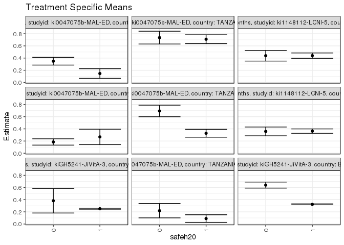

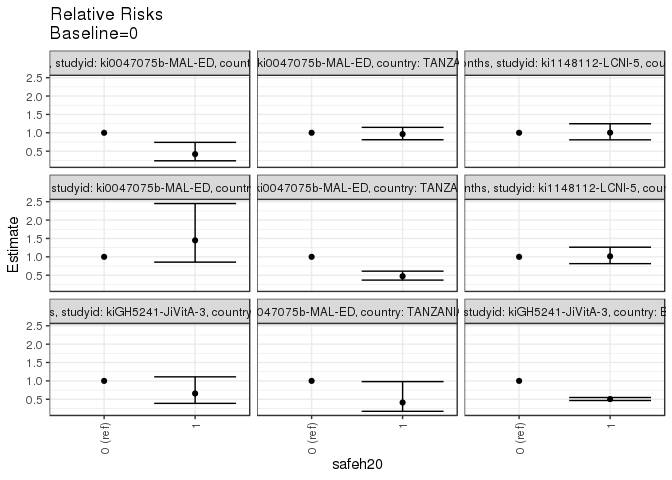

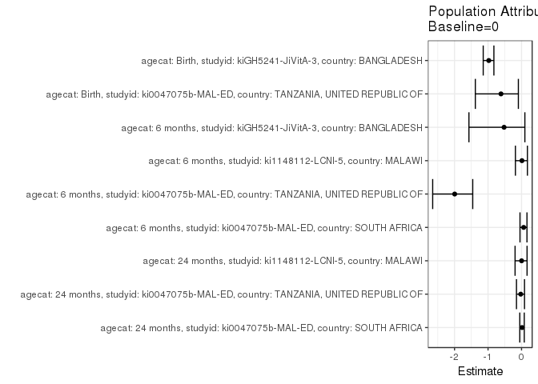

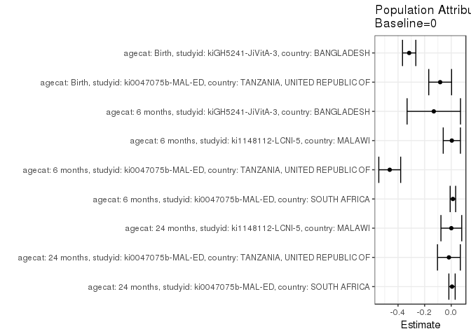

## Results Table

### Parameter: TSM

| agecat | studyid | country | intervention_level | baseline_level | estimate | ci_lower | ci_upper |
| --- | --- | --- | --- | --- | --- | --- | --- |
| Birth | ki0047075b-MAL-ED | TANZANIA, UNITED REPUBLIC OF | 0 | NA | 0.2188095 | 0.1012086 | 0.3364103 |
| Birth | ki0047075b-MAL-ED | TANZANIA, UNITED REPUBLIC OF | 1 | NA | 0.0901138 | 0.0277006 | 0.1525271 |
| Birth | kiGH5241-JiVitA-3 | BANGLADESH | 0 | NA | 0.6394958 | 0.5897219 | 0.6892698 |
| Birth | kiGH5241-JiVitA-3 | BANGLADESH | 1 | NA | 0.3230636 | 0.3153924 | 0.3307348 |
| 6 months | ki0047075b-MAL-ED | SOUTH AFRICA | 0 | NA | 0.1849738 | 0.1334273 | 0.2365203 |
| 6 months | ki0047075b-MAL-ED | SOUTH AFRICA | 1 | NA | 0.2678925 | 0.1409844 | 0.3948005 |
| 6 months | ki0047075b-MAL-ED | TANZANIA, UNITED REPUBLIC OF | 0 | NA | 0.6941279 | 0.5991331 | 0.7891227 |
| 6 months | ki0047075b-MAL-ED | TANZANIA, UNITED REPUBLIC OF | 1 | NA | 0.3283941 | 0.2633673 | 0.3934210 |
| 6 months | ki1148112-LCNI-5 | MALAWI | 0 | NA | 0.3582992 | 0.2859656 | 0.4306329 |
| 6 months | ki1148112-LCNI-5 | MALAWI | 1 | NA | 0.3634788 | 0.3276117 | 0.3993460 |
| 6 months | kiGH5241-JiVitA-3 | BANGLADESH | 0 | NA | 0.3824654 | 0.1810041 | 0.5839267 |
| 6 months | kiGH5241-JiVitA-3 | BANGLADESH | 1 | NA | 0.2512278 | 0.2431141 | 0.2593416 |
| 24 months | ki0047075b-MAL-ED | SOUTH AFRICA | 0 | NA | 0.3485327 | 0.2847803 | 0.4122851 |
| 24 months | ki0047075b-MAL-ED | SOUTH AFRICA | 1 | NA | 0.1460836 | 0.0668881 | 0.2252790 |
| 24 months | ki0047075b-MAL-ED | TANZANIA, UNITED REPUBLIC OF | 0 | NA | 0.7357859 | 0.6307089 | 0.8408629 |
| 24 months | ki0047075b-MAL-ED | TANZANIA, UNITED REPUBLIC OF | 1 | NA | 0.7097260 | 0.6370697 | 0.7823823 |
| 24 months | ki1148112-LCNI-5 | MALAWI | 0 | NA | 0.4382455 | 0.3508995 | 0.5255915 |
| 24 months | ki1148112-LCNI-5 | MALAWI | 1 | NA | 0.4398583 | 0.3960029 | 0.4837137 |

### Parameter: E(Y)

| agecat | studyid | country | intervention_level | baseline_level | estimate | ci_lower | ci_upper |
| --- | --- | --- | --- | --- | --- | --- | --- |
| Birth | ki0047075b-MAL-ED | TANZANIA, UNITED REPUBLIC OF | NA | NA | 0.1355932 | 0.0735587 | 0.1976277 |
| Birth | kiGH5241-JiVitA-3 | BANGLADESH | NA | NA | 0.3232787 | 0.3156210 | 0.3309364 |
| 6 months | ki0047075b-MAL-ED | SOUTH AFRICA | NA | NA | 0.1975806 | 0.1479246 | 0.2472367 |
| 6 months | ki0047075b-MAL-ED | TANZANIA, UNITED REPUBLIC OF | NA | NA | 0.2317073 | 0.1788752 | 0.2845395 |
| 6 months | ki1148112-LCNI-5 | MALAWI | NA | NA | 0.3627451 | 0.3297365 | 0.3957537 |
| 6 months | kiGH5241-JiVitA-3 | BANGLADESH | NA | NA | 0.2513837 | 0.2432545 | 0.2595129 |
| 24 months | ki0047075b-MAL-ED | SOUTH AFRICA | NA | NA | 0.3544304 | 0.2934024 | 0.4154584 |
| 24 months | ki0047075b-MAL-ED | TANZANIA, UNITED REPUBLIC OF | NA | NA | 0.7183099 | 0.6577588 | 0.7788609 |
| 24 months | ki1148112-LCNI-5 | MALAWI | NA | NA | 0.4390244 | 0.3983906 | 0.4796582 |

### Parameter: RR

| agecat | studyid | country | intervention_level | baseline_level | estimate | ci_lower | ci_upper |
| --- | --- | --- | --- | --- | --- | --- | --- |
| Birth | ki0047075b-MAL-ED | TANZANIA, UNITED REPUBLIC OF | 0 | 0 | 1.0000000 | 1.0000000 | 1.0000000 |
| Birth | ki0047075b-MAL-ED | TANZANIA, UNITED REPUBLIC OF | 1 | 0 | 0.4118369 | 0.1728989 | 0.9809761 |
| Birth | kiGH5241-JiVitA-3 | BANGLADESH | 0 | 0 | 1.0000000 | 1.0000000 | 1.0000000 |
| Birth | kiGH5241-JiVitA-3 | BANGLADESH | 1 | 0 | 0.5051848 | 0.4657907 | 0.5479106 |
| 6 months | ki0047075b-MAL-ED | SOUTH AFRICA | 0 | 0 | 1.0000000 | 1.0000000 | 1.0000000 |
| 6 months | ki0047075b-MAL-ED | SOUTH AFRICA | 1 | 0 | 1.4482727 | 0.8560013 | 2.4503393 |
| 6 months | ki0047075b-MAL-ED | TANZANIA, UNITED REPUBLIC OF | 0 | 0 | 1.0000000 | 1.0000000 | 1.0000000 |
| 6 months | ki0047075b-MAL-ED | TANZANIA, UNITED REPUBLIC OF | 1 | 0 | 0.4731032 | 0.3671640 | 0.6096094 |
| 6 months | ki1148112-LCNI-5 | MALAWI | 0 | 0 | 1.0000000 | 1.0000000 | 1.0000000 |
| 6 months | ki1148112-LCNI-5 | MALAWI | 1 | 0 | 1.0144561 | 0.8151493 | 1.2624941 |
| 6 months | kiGH5241-JiVitA-3 | BANGLADESH | 0 | 0 | 1.0000000 | 1.0000000 | 1.0000000 |
| 6 months | kiGH5241-JiVitA-3 | BANGLADESH | 1 | 0 | 0.6568642 | 0.3884359 | 1.1107897 |
| 24 months | ki0047075b-MAL-ED | SOUTH AFRICA | 0 | 0 | 1.0000000 | 1.0000000 | 1.0000000 |
| 24 months | ki0047075b-MAL-ED | SOUTH AFRICA | 1 | 0 | 0.4191388 | 0.2376059 | 0.7393643 |
| 24 months | ki0047075b-MAL-ED | TANZANIA, UNITED REPUBLIC OF | 0 | 0 | 1.0000000 | 1.0000000 | 1.0000000 |
| 24 months | ki0047075b-MAL-ED | TANZANIA, UNITED REPUBLIC OF | 1 | 0 | 0.9645822 | 0.8111043 | 1.1471013 |
| 24 months | ki1148112-LCNI-5 | MALAWI | 0 | 0 | 1.0000000 | 1.0000000 | 1.0000000 |
| 24 months | ki1148112-LCNI-5 | MALAWI | 1 | 0 | 1.0036801 | 0.8083224 | 1.2462524 |

### Parameter: PAR

| agecat | studyid | country | intervention_level | baseline_level | estimate | ci_lower | ci_upper |
| --- | --- | --- | --- | --- | --- | --- | --- |
| Birth | ki0047075b-MAL-ED | TANZANIA, UNITED REPUBLIC OF | 0 | NA | -0.0832163 | -0.1690631 | 0.0026306 |
| Birth | kiGH5241-JiVitA-3 | BANGLADESH | 0 | NA | -0.3162171 | -0.3662790 | -0.2661552 |
| 6 months | ki0047075b-MAL-ED | SOUTH AFRICA | 0 | NA | 0.0126069 | -0.0080573 | 0.0332710 |
| 6 months | ki0047075b-MAL-ED | TANZANIA, UNITED REPUBLIC OF | 0 | NA | -0.4624206 | -0.5446488 | -0.3801924 |
| 6 months | ki1148112-LCNI-5 | MALAWI | 0 | NA | 0.0044459 | -0.0602134 | 0.0691051 |
| 6 months | kiGH5241-JiVitA-3 | BANGLADESH | 0 | NA | -0.1310817 | -0.3318585 | 0.0696950 |
| 24 months | ki0047075b-MAL-ED | SOUTH AFRICA | 0 | NA | 0.0058977 | -0.0177809 | 0.0295763 |
| 24 months | ki0047075b-MAL-ED | TANZANIA, UNITED REPUBLIC OF | 0 | NA | -0.0174760 | -0.1033062 | 0.0683541 |
| 24 months | ki1148112-LCNI-5 | MALAWI | 0 | NA | 0.0007789 | -0.0773747 | 0.0789325 |

### Parameter: PAF

| agecat | studyid | country | intervention_level | baseline_level | estimate | ci_lower | ci_upper |
| --- | --- | --- | --- | --- | --- | --- | --- |
| Birth | ki0047075b-MAL-ED | TANZANIA, UNITED REPUBLIC OF | 0 | NA | -0.6137199 | -1.3792112 | -0.0945190 |
| Birth | kiGH5241-JiVitA-3 | BANGLADESH | 0 | NA | -0.9781563 | -1.1439063 | -0.8252208 |
| 6 months | ki0047075b-MAL-ED | SOUTH AFRICA | 0 | NA | 0.0638062 | -0.0461587 | 0.1622123 |
| 6 months | ki0047075b-MAL-ED | TANZANIA, UNITED REPUBLIC OF | 0 | NA | -1.9957099 | -2.6525123 | -1.4570150 |
| 6 months | ki1148112-LCNI-5 | MALAWI | 0 | NA | 0.0122561 | -0.1830822 | 0.1753423 |
| 6 months | kiGH5241-JiVitA-3 | BANGLADESH | 0 | NA | -0.5214408 | -1.5702882 | 0.0994075 |
| 24 months | ki0047075b-MAL-ED | SOUTH AFRICA | 0 | NA | 0.0166398 | -0.0523206 | 0.0810812 |
| 24 months | ki0047075b-MAL-ED | TANZANIA, UNITED REPUBLIC OF | 0 | NA | -0.0243294 | -0.1510848 | 0.0884679 |
| 24 months | ki1148112-LCNI-5 | MALAWI | 0 | NA | 0.0017741 | -0.1930988 | 0.1648178 |